# Esercitazione N.4

Author

Econometria

# Interazioni

### Pacchetti necessari:

```r
library(tidyverse)
library(knitr)
library(kableExtra)
library(modelsummary)
library(fixest)
library(wooldridge)
data("wage1", package = "wooldridge")
```

**Ripasso dummy e log**

```r
reg_wage_dummy <- feols(wage ~ female, data = wage1, vcov = "hetero")
reg_wagemonthly_dummy <- feols((wage*140) ~ female, data = wage1, vcov = "hetero")
reg_logwage_dummy <- feols(log(wage) ~  female, data = wage1, vcov = "hetero")
reg_logwagemonthly_dummy <- feols(log(wage * 140) ~  female, data = wage1, vcov = "hetero")
modelsummary(list("Wage" = reg_wage_dummy, "Wage Monthly" = reg_wagemonthly_dummy, "Log Wage"= reg_logwage_dummy, "Log (Wage Monthly)" = reg_logwagemonthly_dummy ), output = "kableExtra", gof_omit = "AIC|BIC|RMSE|R2 Adj.")
```

|  | Wage | Wage Monthly | Log Wage | Log (Wage Monthly) |
| --- | --- | --- | --- | --- |
| (Intercept) | 7.099 | 993.928 | 1.814 | 6.755 |
|  | (0.251) | (35.194) | (0.032) | (0.032) |
| female | −2.512 | −351.656 | −0.397 | −0.397 |
|  | (0.298) | (41.667) | (0.043) | (0.043) |
| Num.Obs. | 526 | 526 | 526 | 526 |
| R2 | 0.116 | 0.116 | 0.140 | 0.140 |
| Std.Errors | Heteroskedasticity-robust | Heteroskedasticity-robust | Heteroskedasticity-robust | Heteroskedasticity-robust |

*Nota: Wage Monthly è pari a Wage x 140*

Interpretate i coefficienti:

- Cosa rappresenta l’intercetta uguale a 7.099 e il coefficiente associato a female pari a -2.51?
- Coefficienti nelle regressioni log?
- Intercetta nella regressione log(Wage Monthly) è uguale a $\beta_0 + log(140)$.

Nelle scorse esercitazioni abbiamo creato 3 dummy (donne sposate, uomini sposati e donne single) e interpetato i coefficienti rispetto agli uomini single (la categoria omessa):

```r
wage1 <- wage1 %>%
  mutate(
    marrmale = ifelse(female == 0 & married == 1, 1, 0),
    marrfemale = ifelse(female == 1 & married == 1, 1, 0),
    singfem = ifelse(female == 1 & married == 0, 1, 0)
  )
```

Per semplicità (senza altri regressori):

```r
reg_wage_sm1 <- feols(wage ~ marrmale + marrfemale + singfem, data = wage1, vcov = "hetero")
modelsummary(list("Wage" = reg_wage_sm1), output = "markdown", gof_omit = "AIC|BIC|RMSE|R2 Adj.")
```

|  | Wage |
| --- | --- |
| (Intercept) | 5.168 |
|  | (0.293) |
| marrmale | 2.815 |
|  | (0.435) |
| marrfemale | -0.602 |
|  | (0.342) |
| singfem | -0.556 |
|  | (0.401) |
| Num.Obs. | 526 |
| R2 | 0.181 |
| Std.Errors | Heteroskedasticity-robust |

Come si interpretano i coefficienti?

1. L’intercetta rappresenta il salario orario medio in dollari della categoria omessa (**uomini single**). Quando $marrmale$, $marrfemale$ e $singfem$ sono uguali a zero
2. il coefficiente associato a $marrmale$: in media gli uomini sposati gudagnano 2.815 dollari in più rispetto agli uomini single
3. le donne sposate guadagnano in media 0.60 dollari all’ora in meno rispetto agli uomini single
4. le donne single guadagnano guadagnano in media 0.55 dollari all’ora in meno rispetto agli uomini single

**Nota:** non stiamo controllando per anni di istruzioni, anni di esperrienza…

## Interazione tra due variabili dummy:

Ora creiamo l’interazione tra due variabili dummy: $female$ e $married$. Ciò consente di vedere se “ritorno” del matrimonio dipende dal genere.

```r
reg_wage_marrfe <- feols(wage ~ female * married, data = wage1, vcov = "hetero")
modelsummary(list("Wage" = reg_wage_marrfe), output = "markdown", gof_omit = "AIC|BIC|RMSE|R2 Adj.")
```

|  | Wage |
| --- | --- |
| (Intercept) | 5.168 |
|  | (0.293) |
| female | -0.556 |
|  | (0.401) |
| married | 2.815 |
|  | (0.435) |
| female × married | -2.861 |
|  | (0.543) |
| Num.Obs. | 526 |
| R2 | 0.181 |
| Std.Errors | Heteroskedasticity-robust |

I risultati della regressione mostrano che l’interazione tra genere e stato coniugale è statisticamente significativa (calcolate il valore critico).

Coefficiente di $female$ rappresenta la differenza salariale tra donne e uomini non sposati. In media le donne non sposate guadagnano 0.556 dollari all’ora in meno rispetto agli uomini non sposati.

Coefficiente di $married$ rappresenta l’effetto del matrimonio sul salario orario degli uomini. In media gli uomini sposati guadagnano 2.815 dollari all’ora in più rispetto agli uomini non sposati (single).

Coefficiente dell’interazione $female*married$ rappresenta la differenza nell’effetto del matrimonio tra donne e uomini. L’effetto del matrimonio sul salario orario è 2.861 dollari inferiore per le donne rispetto agli uomini.

In media le donne sposate guadagnano 0.046 dollari in meno rispetto alle donne non sposate ($2,815 - 2,861 = -0,046$).

**Nota**

**Possiamo usare la regressione stimata per stimare il salario medio orario per ciascuna delle quattro combinazioni possibili:**

- L’intercetta uguale a 5.168 rappresenta il salario orario medio per gli uomini single cioè quando $female$ = 0 e $married$ = 0
- Considerando $female$ = 0 e $married$ = 1 otteniamo 7.983 (5.168 + 2.815) che rappresenta il salario orario medio in dollari degli uomini sposati.
- Quando $female$ = 1 e $married$ = 0 otteniamo 4.612 (5.168 - 0.556), che rappresenta il salario orario medio delle donne single
- Quando $female$ = 1 e $married$ = 1 otteniamo 4.566 (5.168 - 0.556 + 2.815 - 2.861) salario orario medio delle donne sposate

**Nota:** non stiamo controllando per altri fattori come anni di istruzione…

Se l’interazione fosse con $male$?

```r
wage1 <- wage1 %>%
  mutate(male = 1 - female)
```

```r
reg_wage_marrmal <- feols(wage ~ male * married, data = wage1, vcov = "hetero")
modelsummary(list("Wage" = reg_wage_marrfe, "Wage" = reg_wage_marrmal), output = "kableExtra", gof_omit = "AIC|BIC|RMSE|R2 Adj.")
```

|  | Wage | Wage |
| --- | --- | --- |
| (Intercept) | 5.168 | 4.612 |
|  | (0.293) | (0.273) |
| female | −0.556 |  |
|  | (0.401) |  |
| married | 2.815 | −0.046 |
|  | (0.435) | (0.325) |
| female × married | −2.861 |  |
|  | (0.543) |  |
| male |  | 0.556 |
|  |  | (0.401) |
| male × married |  | 2.861 |
|  |  | (0.543) |
| Num.Obs. | 526 | 526 |
| R2 | 0.181 | 0.181 |
| Std.Errors | Heteroskedasticity-robust | Heteroskedasticity-robust |

In questo caso il coefficiente di $married$ rappresenta l’effetto del matrimonio sul salario orario delle donne. In media le donne sposate guadagnano 0.046 dollari all’ora in meno rispetto alle donne non sposate.

L’intercetta rappresenta il salario medio per le donne single cioè quando $male$ = 0 e $married$ = 0.

## Interazione tra variabile dummy e continua

In questa esercitazione consideriamo il caso che il libro (Stock e Watson p. 220) definisce pendenza e intercette diverse.

```r
##Prima modello regressione di wage su educ, female e la loro interazione
reg_wage_educfe <- feols(wage ~ educ * female, data = wage1, vcov = "hetero")


#Risultati
modelsummary(list("Wage" = reg_wage_educfe), output = "kableExtra", gof_omit = "AIC|BIC|RMSE|R2 Adj.")
```

|  | Wage |
| --- | --- |
| (Intercept) | 0.200 |
|  | (0.872) |
| educ | 0.539 |
|  | (0.073) |
| female | −1.199 |
|  | (1.461) |
| educ × female | −0.086 |
|  | (0.124) |
| Num.Obs. | 526 |
| R2 | 0.260 |
| Std.Errors | Heteroskedasticity-robust |

- Coefficiente di $educ$ rappresenta l’effetto di un anno aggiuntivo di istruzione sul salario per gli uomini (quando $female$ = 0). L’effetto di un anno aggiuntivo di istruzione per gli uomini è pari a 0.539$
- Coefficiente di $female$ rappresenta la differenza salariale tra donne e uomini quando l’istruzione è zero ($educ$ = 0).
- Coefficiente di $educ* female$ rappresenta la differenza nell’effetto dell’istruzione tra donne e uomini. Le donne ricevono un “premio” per l’istruzione inferiore di circa 0.086$ all’ora rispetto agli uomini. Ogni anno di istruzione in più è meno remunerativo per le donne rispetto agli uomini di circa 0.086$ all’ora.
- L’effetto di un anno aggiuntivo di istruzione per le donne è pari a $\beta_1 + \beta_3$ cioè $0.539 - 0.086 = 0.453$ dollari

E infatti $0.453 - 0.539 = - 0.086$

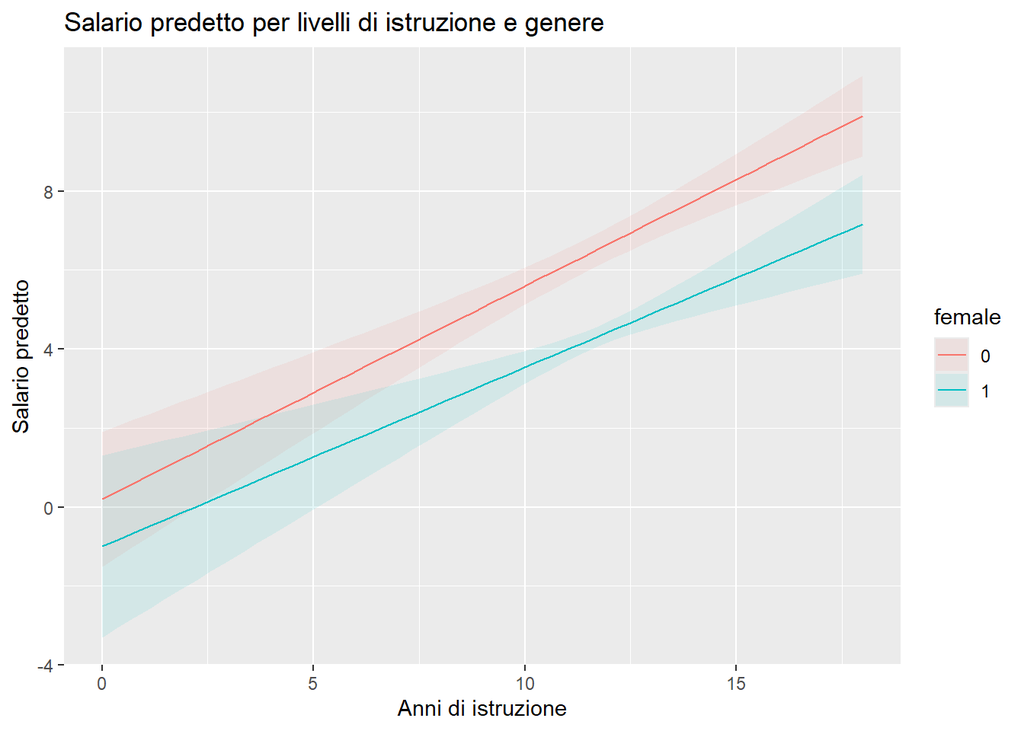

```r
##install.packages("marginaleffects")
library(marginaleffects)
plot_predictions(reg_wage_educfe,
                condition = c("educ", "female"),
                ) +
  labs(title = "Salario predetto per livelli di istruzione e genere",
       x = "Anni di istruzione",
       y = "Salario predetto")
```

## Interazione tra due variabili continue

```r
reg_wage_educexper <- feols(wage ~ educ * exper, data = wage1, vcov = "hetero")

reg_wage_educexper2 <- feols(wage ~ educ * exper + female + tenure, data = wage1, vcov = "hetero")
#Risultati
modelsummary(list("Wage" = reg_wage_educexper, "Wage" = reg_wage_educexper2), output = "kableExtra", gof_omit = "AIC|BIC|RMSE|R2 Adj.")
```

|  | Wage | Wage |
| --- | --- | --- |
| (Intercept) | −2.860 | −0.700 |
|  | (1.069) | (1.170) |
| educ | 0.602 | 0.503 |
|  | (0.087) | (0.090) |
| exper | 0.046 | −0.013 |
|  | (0.036) | (0.040) |
| educ × exper | 0.002 | 0.003 |
|  | (0.003) | (0.003) |
| female |  | −1.841 |
|  |  | (0.265) |
| tenure |  | 0.140 |
|  |  | (0.028) |
| Num.Obs. | 526 | 526 |
| R2 | 0.226 | 0.365 |
| Std.Errors | Heteroskedasticity-robust | Heteroskedasticity-robust |

- il coefficiente associato a $educ$ rappresenta l’effetto di un anno aggiuntivo di istruzione sul salario quando l’esperienza ($exper$) è zero.
- il coefficiente di $exper$: rappresenta l’effetto di un anno aggiuntivo di esperienza sul salario quando l’istruzione ($educ$) è zero.

Il coefficiente di interazione è positivo, significa che l’effetto dell’istruzione aumenta con l’esperienza (o viceversa).

Qual è l’effetto parziale di $educ$ su $wage$?

Per stimare l’effetto parziale consideriamo dei valori rilevanti di $exper$ come la mediana, la media o il terzo quartile:

```r
summary(wage1$exper)
```

```
   Min. 1st Qu.  Median    Mean 3rd Qu.    Max.
   1.00    5.00   13.50   17.02   26.00   51.00
```

$0.602+0.002*13.5 = 0.632$

- Per un individuo con 13.5 anni di esperienza, un anno in più di istruzione è associato a un aumento medio del salario orario di circa 0.632 dollari
- Per un individuo con 26 anni di esperienza (terzo quartile), un anno in più di istruzione è associato a un aumento medio del salario orario di circa $0.602+0.002*26 = 0.654$ dollari